# Week-4 Graded project by Saranram

#### Week-4 Graded Project by Saranram K C

#### Task-1

#### 1. Import required libraries and read the dataset.

```python
#Import necessary libraries:
import numpy as np
import pandas as pd
import matplotlib.pyplot as plt
import seaborn as sns
import math
from scipy import stats
from sklearn.preprocessing import LabelEncoder
from sklearn.linear_model import LinearRegression
from sklearn.model_selection import train_test_split
from sklearn.preprocessing import StandardScaler
from sklearn import metrics
from sklearn.metrics import mean_squared_error
from sklearn.metrics import r2_score
import statsmodels.formula.api as smf
import warnings
warnings.filterwarnings('ignore')
```

```python
#Read the dataset.
df=pd.read_csv("Apps_data+(1).csv")
df
```

|  | App | Category | Rating | Reviews | Size | Installs | Type | Price | Content Rating | Genres | Last Updated | Current Ver | Android Ver |
| --- | --- | --- | --- | --- | --- | --- | --- | --- | --- | --- | --- | --- | --- |
| 0 | Photo Editor & Candy Camera & Grid & ScrapBook | ART_AND_DESIGN | 4.1 | 159 | 19M | 10,000+ | Free | 0 | Everyone | Art & Design | January 7, 2018 | 1.0.0 | 4.0.3 and up |
| 1 | Coloring book moana | ART_AND_DESIGN | 3.9 | 967 | 14M | 500,000+ | Free | 0 | Everyone | Art & Design;Pretend Play | January 15, 2018 | 2.0.0 | 4.0.3 and up |
| 2 | U Launcher Lite – FREE Live Cool Themes, Hide ... | ART_AND_DESIGN | 4.7 | 87510 | 8.7M | 5,000,000+ | Free | 0 | Everyone | Art & Design | August 1, 2018 | 1.2.4 | 4.0.3 and up |
| 3 | Sketch - Draw & Paint | ART_AND_DESIGN | 4.5 | 215644 | 25M | 50,000,000+ | Free | 0 | Teen | Art & Design | June 8, 2018 | Varies with device | 4.2 and up |
| 4 | Pixel Draw - Number Art Coloring Book | ART_AND_DESIGN | 4.3 | 967 | 2.8M | 100,000+ | Free | 0 | Everyone | Art & Design;Creativity | June 20, 2018 | 1.1 | 4.4 and up |
| ... | ... | ... | ... | ... | ... | ... | ... | ... | ... | ... | ... | ... | ... |
| 10836 | Sya9a Maroc - FR | FAMILY | 4.5 | 38 | 53M | 5,000+ | Free | 0 | Everyone | Education | July 25, 2017 | 1.48 | 4.1 and up |
| 10837 | Fr. Mike Schmitz Audio Teachings | FAMILY | 5.0 | 4 | 3.6M | 100+ | Free | 0 | Everyone | Education | July 6, 2018 | 1.0 | 4.1 and up |
| 10838 | Parkinson Exercices FR | MEDICAL | NaN | 3 | 9.5M | 1,000+ | Free | 0 | Everyone | Medical | January 20, 2017 | 1.0 | 2.2 and up |
| 10839 | The SCP Foundation DB fr nn5n | BOOKS_AND_REFERENCE | 4.5 | 114 | Varies with device | 1,000+ | Free | 0 | Mature 17+ | Books & Reference | January 19, 2015 | Varies with device | Varies with device |
| 10840 | iHoroscope - 2018 Daily Horoscope & Astrology | LIFESTYLE | 4.5 | 398307 | 19M | 10,000,000+ | Free | 0 | Everyone | Lifestyle | July 25, 2018 | Varies with device | Varies with device |

10841 rows × 13 columns

#### 2. Check the first few samples, shape, info of the data and try to familiarize yourself with different features.

```python
# lets check top few records to get a feel of the data structure
df.head()
```

|  | App | Category | Rating | Reviews | Size | Installs | Type | Price | Content Rating | Genres | Last Updated | Current Ver | Android Ver |
| --- | --- | --- | --- | --- | --- | --- | --- | --- | --- | --- | --- | --- | --- |
| 0 | Photo Editor & Candy Camera & Grid & ScrapBook | ART_AND_DESIGN | 4.1 | 159 | 19M | 10,000+ | Free | 0 | Everyone | Art & Design | January 7, 2018 | 1.0.0 | 4.0.3 and up |
| 1 | Coloring book moana | ART_AND_DESIGN | 3.9 | 967 | 14M | 500,000+ | Free | 0 | Everyone | Art & Design;Pretend Play | January 15, 2018 | 2.0.0 | 4.0.3 and up |
| 2 | U Launcher Lite – FREE Live Cool Themes, Hide ... | ART_AND_DESIGN | 4.7 | 87510 | 8.7M | 5,000,000+ | Free | 0 | Everyone | Art & Design | August 1, 2018 | 1.2.4 | 4.0.3 and up |
| 3 | Sketch - Draw & Paint | ART_AND_DESIGN | 4.5 | 215644 | 25M | 50,000,000+ | Free | 0 | Teen | Art & Design | June 8, 2018 | Varies with device | 4.2 and up |
| 4 | Pixel Draw - Number Art Coloring Book | ART_AND_DESIGN | 4.3 | 967 | 2.8M | 100,000+ | Free | 0 | Everyone | Art & Design;Creativity | June 20, 2018 | 1.1 | 4.4 and up |

```python
# lets check bottom few records to get a feel of the data structure
df.tail()
```

|  | App | Category | Rating | Reviews | Size | Installs | Type | Price | Content Rating | Genres | Last Updated | Current Ver | Android Ver |
| --- | --- | --- | --- | --- | --- | --- | --- | --- | --- | --- | --- | --- | --- |
| 10836 | Sya9a Maroc - FR | FAMILY | 4.5 | 38 | 53M | 5,000+ | Free | 0 | Everyone | Education | July 25, 2017 | 1.48 | 4.1 and up |
| 10837 | Fr. Mike Schmitz Audio Teachings | FAMILY | 5.0 | 4 | 3.6M | 100+ | Free | 0 | Everyone | Education | July 6, 2018 | 1.0 | 4.1 and up |
| 10838 | Parkinson Exercices FR | MEDICAL | NaN | 3 | 9.5M | 1,000+ | Free | 0 | Everyone | Medical | January 20, 2017 | 1.0 | 2.2 and up |
| 10839 | The SCP Foundation DB fr nn5n | BOOKS_AND_REFERENCE | 4.5 | 114 | Varies with device | 1,000+ | Free | 0 | Mature 17+ | Books & Reference | January 19, 2015 | Varies with device | Varies with device |
| 10840 | iHoroscope - 2018 Daily Horoscope & Astrology | LIFESTYLE | 4.5 | 398307 | 19M | 10,000,000+ | Free | 0 | Everyone | Lifestyle | July 25, 2018 | Varies with device | Varies with device |

```python
# lets check basic information of the dataset.
df.info()
```

```
<class 'pandas.core.frame.DataFrame'>
RangeIndex: 10841 entries, 0 to 10840
Data columns (total 13 columns):
 #   Column          Non-Null Count  Dtype
---  ------          --------------  -----
 0   App             10841 non-null  object
 1   Category        10841 non-null  object
 2   Rating          9367 non-null   float64
 3   Reviews         10841 non-null  object
 4   Size            10841 non-null  object
 5   Installs        10841 non-null  object
 6   Type            10840 non-null  object
 7   Price           10841 non-null  object
 8   Content Rating  10840 non-null  object
 9   Genres          10841 non-null  object
 10  Last Updated    10841 non-null  object
 11  Current Ver     10833 non-null  object
 12  Android Ver     10838 non-null  object
dtypes: float64(1), object(12)
memory usage: 1.1+ MB
```

```python
##checking number of rows and columns in the dataset.
df.shape
```

```
(10841, 13)
```

- The given dataset have 10,841 rows and 13 columns.

```python
#check basic information of the datatypes
df.dtypes
```

```
App                object
Category           object
Rating            float64
Reviews            object
Size               object
Installs           object
Type               object
Price              object
Content Rating     object
Genres             object
Last Updated       object
Current Ver        object
Android Ver        object
dtype: object
```

```python
#checking counts of the columns in the dataset
df.count()
```

```
App               10841
Category          10841
Rating             9367
Reviews           10841
Size              10841
Installs          10841
Type              10840
Price             10841
Content Rating    10840
Genres            10841
Last Updated      10841
Current Ver       10833
Android Ver       10838
dtype: int64
```

#### 3. Check summary statistics of the dataset. List out the columns that need to be worked upon for model building.

```python
# lets check statistical summary of the data.
df.describe(include='all').T
```

|  | count | unique | top | freq | mean | std | min | 25% | 50% | 75% | max |
| --- | --- | --- | --- | --- | --- | --- | --- | --- | --- | --- | --- |
| App | 10841 | 9660 | ROBLOX | 9 | NaN | NaN | NaN | NaN | NaN | NaN | NaN |
| Category | 10841 | 34 | FAMILY | 1972 | NaN | NaN | NaN | NaN | NaN | NaN | NaN |
| Rating | 9367.0 | NaN | NaN | NaN | 4.193338 | 0.537431 | 1.0 | 4.0 | 4.3 | 4.5 | 19.0 |
| Reviews | 10841 | 6002 | 0 | 596 | NaN | NaN | NaN | NaN | NaN | NaN | NaN |
| Size | 10841 | 462 | Varies with device | 1695 | NaN | NaN | NaN | NaN | NaN | NaN | NaN |
| Installs | 10841 | 22 | 1,000,000+ | 1579 | NaN | NaN | NaN | NaN | NaN | NaN | NaN |
| Type | 10840 | 3 | Free | 10039 | NaN | NaN | NaN | NaN | NaN | NaN | NaN |
| Price | 10841 | 93 | 0 | 10040 | NaN | NaN | NaN | NaN | NaN | NaN | NaN |
| Content Rating | 10840 | 6 | Everyone | 8714 | NaN | NaN | NaN | NaN | NaN | NaN | NaN |
| Genres | 10841 | 120 | Tools | 842 | NaN | NaN | NaN | NaN | NaN | NaN | NaN |
| Last Updated | 10841 | 1378 | August 3, 2018 | 326 | NaN | NaN | NaN | NaN | NaN | NaN | NaN |
| Current Ver | 10833 | 2832 | Varies with device | 1459 | NaN | NaN | NaN | NaN | NaN | NaN | NaN |
| Android Ver | 10838 | 33 | 4.1 and up | 2451 | NaN | NaN | NaN | NaN | NaN | NaN | NaN |

- **App**: There are 10,000 apps in the given dataset, but some apps are appear multiple times in the dataset.
- **Category**: The apps belong to 34 unique categories.
- **Rating**: The average rating of the apps is around 4.2 out of 5, with ratings ranging from 1 to 19.
- **Reviews**: The most common number of reviews is 0, which occurs 596 times.
- **Size**: App sizes vary widely, with some apps having a size listed as "Varies with device" and others having specific sizes.
- **Installs**: The number of installs ranges from a few to over a million.
- **Type**: Most apps in the dataset are free, but there are also paid and partially paid apps.
- **Price**: While many apps are free, there are also various price points for some paid apps.
- **Content Rating**: The majority of apps are rated "Everyone," indicating they are suitable for all audiences.
- **Genres**: There are many different genres represented in the dataset, with "Tools" being the most common.
- **Last Updated**: The last update dates of the apps range widely, with some apps last updated recently.
- **Current Ver**: The versions of the apps vary, with some apps having specific versions and others listed as "Varies with device."
- **Android Ver**: The supported Android versions also vary, with some apps supporting older versions and others requiring newer ones like "4.1 and up."

#### 4. Check if there are any duplicate records in the dataset? if any drop them.

```python
#Let check number of duplicates in the given dataset
df.duplicated().sum()
```

```
483
```

- There are 483 duplicates in the dataset.

```python
#droping duplicates
df=df.drop_duplicates()
```

```python
df.duplicated().sum()
```

```
0
```

```python
df['Category']
```

```
0             ART_AND_DESIGN
1             ART_AND_DESIGN
2             ART_AND_DESIGN
3             ART_AND_DESIGN
4             ART_AND_DESIGN
                ...
10836                 FAMILY
10837                 FAMILY
10838                MEDICAL
10839    BOOKS_AND_REFERENCE
10840              LIFESTYLE
Name: Category, Length: 10358, dtype: object
```

#### 5. Check the unique categories of the column 'Category', Is there any invalid category? If yes, drop them.

```python
df['Category'].unique()
```

```
array(['ART_AND_DESIGN', 'AUTO_AND_VEHICLES', 'BEAUTY',
       'BOOKS_AND_REFERENCE', 'BUSINESS', 'COMICS', 'COMMUNICATION',
       'DATING', 'EDUCATION', 'ENTERTAINMENT', 'EVENTS', 'FINANCE',
       'FOOD_AND_DRINK', 'HEALTH_AND_FITNESS', 'HOUSE_AND_HOME',
       'LIBRARIES_AND_DEMO', 'LIFESTYLE', 'GAME', 'FAMILY', 'MEDICAL',
       'SOCIAL', 'SHOPPING', 'PHOTOGRAPHY', 'SPORTS', 'TRAVEL_AND_LOCAL',
       'TOOLS', 'PERSONALIZATION', 'PRODUCTIVITY', 'PARENTING', 'WEATHER',
       'VIDEO_PLAYERS', 'NEWS_AND_MAGAZINES', 'MAPS_AND_NAVIGATION',
       '1.9'], dtype=object)
```

```python
df.drop(df[df['Category'].isin(['1.9'])].index, inplace=True)
df
```

|  | App | Category | Rating | Reviews | Size | Installs | Type | Price | Content Rating | Genres | Last Updated | Current Ver | Android Ver |
| --- | --- | --- | --- | --- | --- | --- | --- | --- | --- | --- | --- | --- | --- |
| 0 | Photo Editor & Candy Camera & Grid & ScrapBook | ART_AND_DESIGN | 4.1 | 159 | 19M | 10,000+ | Free | 0 | Everyone | Art & Design | January 7, 2018 | 1.0.0 | 4.0.3 and up |
| 1 | Coloring book moana | ART_AND_DESIGN | 3.9 | 967 | 14M | 500,000+ | Free | 0 | Everyone | Art & Design;Pretend Play | January 15, 2018 | 2.0.0 | 4.0.3 and up |
| 2 | U Launcher Lite – FREE Live Cool Themes, Hide ... | ART_AND_DESIGN | 4.7 | 87510 | 8.7M | 5,000,000+ | Free | 0 | Everyone | Art & Design | August 1, 2018 | 1.2.4 | 4.0.3 and up |
| 3 | Sketch - Draw & Paint | ART_AND_DESIGN | 4.5 | 215644 | 25M | 50,000,000+ | Free | 0 | Teen | Art & Design | June 8, 2018 | Varies with device | 4.2 and up |
| 4 | Pixel Draw - Number Art Coloring Book | ART_AND_DESIGN | 4.3 | 967 | 2.8M | 100,000+ | Free | 0 | Everyone | Art & Design;Creativity | June 20, 2018 | 1.1 | 4.4 and up |
| ... | ... | ... | ... | ... | ... | ... | ... | ... | ... | ... | ... | ... | ... |
| 10836 | Sya9a Maroc - FR | FAMILY | 4.5 | 38 | 53M | 5,000+ | Free | 0 | Everyone | Education | July 25, 2017 | 1.48 | 4.1 and up |
| 10837 | Fr. Mike Schmitz Audio Teachings | FAMILY | 5.0 | 4 | 3.6M | 100+ | Free | 0 | Everyone | Education | July 6, 2018 | 1.0 | 4.1 and up |
| 10838 | Parkinson Exercices FR | MEDICAL | NaN | 3 | 9.5M | 1,000+ | Free | 0 | Everyone | Medical | January 20, 2017 | 1.0 | 2.2 and up |
| 10839 | The SCP Foundation DB fr nn5n | BOOKS_AND_REFERENCE | 4.5 | 114 | Varies with device | 1,000+ | Free | 0 | Mature 17+ | Books & Reference | January 19, 2015 | Varies with device | Varies with device |
| 10840 | iHoroscope - 2018 Daily Horoscope & Astrology | LIFESTYLE | 4.5 | 398307 | 19M | 10,000,000+ | Free | 0 | Everyone | Lifestyle | July 25, 2018 | Varies with device | Varies with device |

10357 rows × 13 columns

#### 6. Check if there are missing values present in the column Rating, If any? drop them and and create a new column as 'Rating_category' by converting ratings to high and low categories(>3.5 is high rest low)

```python
#checking Number of missing values in the Rating Column
df['Rating'].isnull().sum()
```

```
1465
```

```python
df.dropna(subset=['Rating'],inplace=True)
```

```python
#checking Number of missing values in the Rating Column after droped missing Values
df['Rating'].isnull().sum()
```

```
0
```

```python
#creating new column as 'Rating_category' & converting ratings to high and low categories
df['Rating_category']=df['Rating'].apply(lambda x: 'High' if x > 3.5 else 'Low')
df
```

|  | App | Category | Rating | Reviews | Size | Installs | Type | Price | Content Rating | Genres | Last Updated | Current Ver | Android Ver | Rating_category |
| --- | --- | --- | --- | --- | --- | --- | --- | --- | --- | --- | --- | --- | --- | --- |
| 0 | Photo Editor & Candy Camera & Grid & ScrapBook | ART_AND_DESIGN | 4.1 | 159 | 19M | 10,000+ | Free | 0 | Everyone | Art & Design | January 7, 2018 | 1.0.0 | 4.0.3 and up | High |
| 1 | Coloring book moana | ART_AND_DESIGN | 3.9 | 967 | 14M | 500,000+ | Free | 0 | Everyone | Art & Design;Pretend Play | January 15, 2018 | 2.0.0 | 4.0.3 and up | High |
| 2 | U Launcher Lite – FREE Live Cool Themes, Hide ... | ART_AND_DESIGN | 4.7 | 87510 | 8.7M | 5,000,000+ | Free | 0 | Everyone | Art & Design | August 1, 2018 | 1.2.4 | 4.0.3 and up | High |
| 3 | Sketch - Draw & Paint | ART_AND_DESIGN | 4.5 | 215644 | 25M | 50,000,000+ | Free | 0 | Teen | Art & Design | June 8, 2018 | Varies with device | 4.2 and up | High |
| 4 | Pixel Draw - Number Art Coloring Book | ART_AND_DESIGN | 4.3 | 967 | 2.8M | 100,000+ | Free | 0 | Everyone | Art & Design;Creativity | June 20, 2018 | 1.1 | 4.4 and up | High |
| ... | ... | ... | ... | ... | ... | ... | ... | ... | ... | ... | ... | ... | ... | ... |
| 10834 | FR Calculator | FAMILY | 4.0 | 7 | 2.6M | 500+ | Free | 0 | Everyone | Education | June 18, 2017 | 1.0.0 | 4.1 and up | High |
| 10836 | Sya9a Maroc - FR | FAMILY | 4.5 | 38 | 53M | 5,000+ | Free | 0 | Everyone | Education | July 25, 2017 | 1.48 | 4.1 and up | High |
| 10837 | Fr. Mike Schmitz Audio Teachings | FAMILY | 5.0 | 4 | 3.6M | 100+ | Free | 0 | Everyone | Education | July 6, 2018 | 1.0 | 4.1 and up | High |
| 10839 | The SCP Foundation DB fr nn5n | BOOKS_AND_REFERENCE | 4.5 | 114 | Varies with device | 1,000+ | Free | 0 | Mature 17+ | Books & Reference | January 19, 2015 | Varies with device | Varies with device | High |
| 10840 | iHoroscope - 2018 Daily Horoscope & Astrology | LIFESTYLE | 4.5 | 398307 | 19M | 10,000,000+ | Free | 0 | Everyone | Lifestyle | July 25, 2018 | Varies with device | Varies with device | High |

8892 rows × 14 columns

#### 7. Check the distribution of the newly created column 'Rating_category' and comment on the distribution.

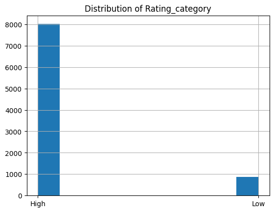

```python
df['Rating_category'].hist()
plt.title('Distribution of Rating_category');
```

```python
df['Rating_category'].value_counts()
```

```
Rating_category
High    8012
Low      880
Name: count, dtype: int64
```

#### 8. Convert the column "Reviews'' to numeric data type and check the presence of outliers in the column and handle the outliers using a transformation approach.(Hint: Use log transformation)

```python
df['Reviews']=pd.to_numeric(df['Reviews'])
df
```

|  | App | Category | Rating | Reviews | Size | Installs | Type | Price | Content Rating | Genres | Last Updated | Current Ver | Android Ver | Rating_category |
| --- | --- | --- | --- | --- | --- | --- | --- | --- | --- | --- | --- | --- | --- | --- |
| 0 | Photo Editor & Candy Camera & Grid & ScrapBook | ART_AND_DESIGN | 4.1 | 159 | 19M | 10,000+ | Free | 0 | Everyone | Art & Design | January 7, 2018 | 1.0.0 | 4.0.3 and up | High |
| 1 | Coloring book moana | ART_AND_DESIGN | 3.9 | 967 | 14M | 500,000+ | Free | 0 | Everyone | Art & Design;Pretend Play | January 15, 2018 | 2.0.0 | 4.0.3 and up | High |
| 2 | U Launcher Lite – FREE Live Cool Themes, Hide ... | ART_AND_DESIGN | 4.7 | 87510 | 8.7M | 5,000,000+ | Free | 0 | Everyone | Art & Design | August 1, 2018 | 1.2.4 | 4.0.3 and up | High |
| 3 | Sketch - Draw & Paint | ART_AND_DESIGN | 4.5 | 215644 | 25M | 50,000,000+ | Free | 0 | Teen | Art & Design | June 8, 2018 | Varies with device | 4.2 and up | High |
| 4 | Pixel Draw - Number Art Coloring Book | ART_AND_DESIGN | 4.3 | 967 | 2.8M | 100,000+ | Free | 0 | Everyone | Art & Design;Creativity | June 20, 2018 | 1.1 | 4.4 and up | High |
| ... | ... | ... | ... | ... | ... | ... | ... | ... | ... | ... | ... | ... | ... | ... |
| 10834 | FR Calculator | FAMILY | 4.0 | 7 | 2.6M | 500+ | Free | 0 | Everyone | Education | June 18, 2017 | 1.0.0 | 4.1 and up | High |
| 10836 | Sya9a Maroc - FR | FAMILY | 4.5 | 38 | 53M | 5,000+ | Free | 0 | Everyone | Education | July 25, 2017 | 1.48 | 4.1 and up | High |
| 10837 | Fr. Mike Schmitz Audio Teachings | FAMILY | 5.0 | 4 | 3.6M | 100+ | Free | 0 | Everyone | Education | July 6, 2018 | 1.0 | 4.1 and up | High |
| 10839 | The SCP Foundation DB fr nn5n | BOOKS_AND_REFERENCE | 4.5 | 114 | Varies with device | 1,000+ | Free | 0 | Mature 17+ | Books & Reference | January 19, 2015 | Varies with device | Varies with device | High |
| 10840 | iHoroscope - 2018 Daily Horoscope & Astrology | LIFESTYLE | 4.5 | 398307 | 19M | 10,000,000+ | Free | 0 | Everyone | Lifestyle | July 25, 2018 | Varies with device | Varies with device | High |

8892 rows × 14 columns

#### Checking outliers

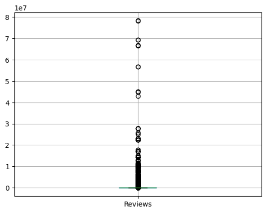

```python
df[['Reviews']].boxplot()
```

- We find the presence of outliers from the box plot displayed above shown. So, we need to treat the outliers.

```python
def detect_outliers_zscore(data):
    threshold = 3
    mean = np.mean(data)
    std = np.std(data)
    outliers = []
    for i in data:
        z_score = (i - mean) / std
        if np.abs(z_score) > threshold:
            outliers.append(i)
    return outliers

sample = [15, 101, 18, 7, 13, 16, 11, 21, 5, 15, 10, 9]
sample_outliers = detect_outliers_zscore(sample)

#log transformation
df['Reviews'] = np.log1p(df['Reviews'])  # Add 1 before taking the log
print(df['Reviews'])
```

```
0         5.075174
1         6.875232
2        11.379520
3        12.281389
4         6.875232
           ...
10834     2.079442
10836     3.663562
10837     1.609438
10839     4.744932
10840    12.894981
Name: Reviews, Length: 8892, dtype: float64
```

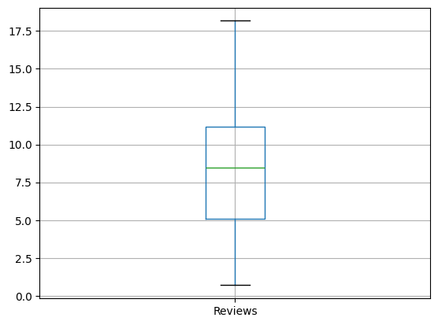

```python
df[['Reviews']].boxplot()
plt.show()
```

- Outliers were treated.

#### 9. The column 'Size' contains alphanumeric values, treat the non numeric data and convert the column into suitable data type. (hint: Replace M with 1 million and K with 1 thousand, and drop the entries where size='Varies with device')

```python
#Checking unique values in the size column
df['Size'].unique()
```

```
array(['19M', '14M', '8.7M', '25M', '2.8M', '5.6M', '29M', '33M', '3.1M',
       '28M', '12M', '20M', '21M', '37M', '2.7M', '5.5M', '17M', '39M',
       '31M', '4.2M', '23M', '6.0M', '6.1M', '4.6M', '9.2M', '5.2M',
       '11M', '24M', 'Varies with device', '9.4M', '15M', '10M', '1.2M',
       '26M', '8.0M', '7.9M', '56M', '57M', '35M', '54M', '201k', '3.6M',
       '5.7M', '8.6M', '2.4M', '27M', '2.5M', '7.0M', '16M', '3.4M',
       '8.9M', '3.9M', '2.9M', '38M', '32M', '5.4M', '18M', '1.1M',
       '2.2M', '4.5M', '9.8M', '52M', '9.0M', '6.7M', '30M', '2.6M',
       '7.1M', '22M', '6.4M', '3.2M', '8.2M', '4.9M', '9.5M', '5.0M',
       '5.9M', '13M', '73M', '6.8M', '3.5M', '4.0M', '2.3M', '2.1M',
       '42M', '9.1M', '55M', '23k', '7.3M', '6.5M', '1.5M', '7.5M', '51M',
       '41M', '48M', '8.5M', '46M', '8.3M', '4.3M', '4.7M', '3.3M', '40M',
       '7.8M', '8.8M', '6.6M', '5.1M', '61M', '66M', '79k', '8.4M',
       '3.7M', '118k', '44M', '695k', '1.6M', '6.2M', '53M', '1.4M',
       '3.0M', '7.2M', '5.8M', '3.8M', '9.6M', '45M', '63M', '49M', '77M',
       '4.4M', '70M', '9.3M', '8.1M', '36M', '6.9M', '7.4M', '84M', '97M',
       '2.0M', '1.9M', '1.8M', '5.3M', '47M', '556k', '526k', '76M',
       '7.6M', '59M', '9.7M', '78M', '72M', '43M', '7.7M', '6.3M', '334k',
       '93M', '65M', '79M', '100M', '58M', '50M', '68M', '64M', '34M',
       '67M', '60M', '94M', '9.9M', '232k', '99M', '624k', '95M', '8.5k',
       '41k', '292k', '11k', '80M', '1.7M', '10.0M', '74M', '62M', '69M',
       '75M', '98M', '85M', '82M', '96M', '87M', '71M', '86M', '91M',
       '81M', '92M', '83M', '88M', '704k', '862k', '899k', '378k', '4.8M',
       '266k', '375k', '1.3M', '975k', '980k', '4.1M', '89M', '696k',
       '544k', '525k', '920k', '779k', '853k', '720k', '713k', '772k',
       '318k', '58k', '241k', '196k', '857k', '51k', '953k', '865k',
       '251k', '930k', '540k', '313k', '746k', '203k', '26k', '314k',
       '239k', '371k', '220k', '730k', '756k', '91k', '293k', '17k',
       '74k', '14k', '317k', '78k', '924k', '818k', '81k', '939k', '169k',
       '45k', '965k', '90M', '545k', '61k', '283k', '655k', '714k', '93k',
       '872k', '121k', '322k', '976k', '206k', '954k', '444k', '717k',
       '210k', '609k', '308k', '306k', '175k', '350k', '383k', '454k',
       '1.0M', '70k', '812k', '442k', '842k', '417k', '412k', '459k',
       '478k', '335k', '782k', '721k', '430k', '429k', '192k', '460k',
       '728k', '496k', '816k', '414k', '506k', '887k', '613k', '778k',
       '683k', '592k', '186k', '840k', '647k', '373k', '437k', '598k',
       '716k', '585k', '982k', '219k', '55k', '323k', '691k', '511k',
       '951k', '963k', '25k', '554k', '351k', '27k', '82k', '208k',
       '551k', '29k', '103k', '116k', '153k', '209k', '499k', '173k',
       '597k', '809k', '122k', '411k', '400k', '801k', '787k', '50k',
       '643k', '986k', '516k', '837k', '780k', '20k', '498k', '600k',
       '656k', '221k', '228k', '176k', '34k', '259k', '164k', '458k',
       '629k', '28k', '288k', '775k', '785k', '636k', '916k', '994k',
       '309k', '485k', '914k', '903k', '608k', '500k', '54k', '562k',
       '847k', '948k', '811k', '270k', '48k', '523k', '784k', '280k',
       '24k', '892k', '154k', '18k', '33k', '860k', '364k', '387k',
       '626k', '161k', '879k', '39k', '170k', '141k', '160k', '144k',
       '143k', '190k', '376k', '193k', '473k', '246k', '73k', '253k',
       '957k', '420k', '72k', '404k', '470k', '226k', '240k', '89k',
       '234k', '257k', '861k', '467k', '676k', '552k', '582k', '619k'],
      dtype=object)
```

```python
df[df['Size']=='Varies with device']
```

|  | App | Category | Rating | Reviews | Size | Installs | Type | Price | Content Rating | Genres | Last Updated | Current Ver | Android Ver | Rating_category |
| --- | --- | --- | --- | --- | --- | --- | --- | --- | --- | --- | --- | --- | --- | --- |
| 37 | Floor Plan Creator | ART_AND_DESIGN | 4.1 | 10.508896 | Varies with device | 5,000,000+ | Free | 0 | Everyone | Art & Design | July 14, 2018 | Varies with device | 2.3.3 and up | High |
| 42 | Textgram - write on photos | ART_AND_DESIGN | 4.4 | 12.595483 | Varies with device | 10,000,000+ | Free | 0 | Everyone | Art & Design | July 30, 2018 | Varies with device | Varies with device | High |
| 52 | Used Cars and Trucks for Sale | AUTO_AND_VEHICLES | 4.6 | 9.744375 | Varies with device | 1,000,000+ | Free | 0 | Everyone | Auto & Vehicles | July 30, 2018 | Varies with device | Varies with device | High |
| 67 | Ulysse Speedometer | AUTO_AND_VEHICLES | 4.3 | 10.601921 | Varies with device | 5,000,000+ | Free | 0 | Everyone | Auto & Vehicles | July 30, 2018 | Varies with device | Varies with device | High |
| 68 | REPUVE | AUTO_AND_VEHICLES | 3.9 | 5.877736 | Varies with device | 100,000+ | Free | 0 | Everyone | Auto & Vehicles | May 25, 2018 | Varies with device | Varies with device | High |
| ... | ... | ... | ... | ... | ... | ... | ... | ... | ... | ... | ... | ... | ... | ... |
| 10713 | My Earthquake Alerts - US & Worldwide Earthquakes | WEATHER | 4.4 | 8.152486 | Varies with device | 100,000+ | Free | 0 | Everyone | Weather | July 24, 2018 | Varies with device | Varies with device | High |
| 10725 | Posta App | MAPS_AND_NAVIGATION | 3.6 | 2.197225 | Varies with device | 1,000+ | Free | 0 | Everyone | Maps & Navigation | September 27, 2017 | Varies with device | 4.4 and up | High |
| 10765 | Chat For Strangers - Video Chat | SOCIAL | 3.4 | 6.434547 | Varies with device | 100,000+ | Free | 0 | Mature 17+ | Social | May 23, 2018 | Varies with device | Varies with device | Low |
| 10826 | Frim: get new friends on local chat rooms | SOCIAL | 4.0 | 11.390611 | Varies with device | 5,000,000+ | Free | 0 | Mature 17+ | Social | March 23, 2018 | Varies with device | Varies with device | High |
| 10839 | The SCP Foundation DB fr nn5n | BOOKS_AND_REFERENCE | 4.5 | 4.744932 | Varies with device | 1,000+ | Free | 0 | Mature 17+ | Books & Reference | January 19, 2015 | Varies with device | Varies with device | High |

1468 rows × 14 columns

```python
df['Size'] = df['Size'].str.replace('M',' million').str.replace('K',' thousand')
df
```

|  | App | Category | Rating | Reviews | Size | Installs | Type | Price | Content Rating | Genres | Last Updated | Current Ver | Android Ver | Rating_category |
| --- | --- | --- | --- | --- | --- | --- | --- | --- | --- | --- | --- | --- | --- | --- |
| 0 | Photo Editor & Candy Camera & Grid & ScrapBook | ART_AND_DESIGN | 4.1 | 5.075174 | 19 million | 10,000+ | Free | 0 | Everyone | Art & Design | January 7, 2018 | 1.0.0 | 4.0.3 and up | High |
| 1 | Coloring book moana | ART_AND_DESIGN | 3.9 | 6.875232 | 14 million | 500,000+ | Free | 0 | Everyone | Art & Design;Pretend Play | January 15, 2018 | 2.0.0 | 4.0.3 and up | High |
| 2 | U Launcher Lite – FREE Live Cool Themes, Hide ... | ART_AND_DESIGN | 4.7 | 11.379520 | 8.7 million | 5,000,000+ | Free | 0 | Everyone | Art & Design | August 1, 2018 | 1.2.4 | 4.0.3 and up | High |
| 3 | Sketch - Draw & Paint | ART_AND_DESIGN | 4.5 | 12.281389 | 25 million | 50,000,000+ | Free | 0 | Teen | Art & Design | June 8, 2018 | Varies with device | 4.2 and up | High |
| 4 | Pixel Draw - Number Art Coloring Book | ART_AND_DESIGN | 4.3 | 6.875232 | 2.8 million | 100,000+ | Free | 0 | Everyone | Art & Design;Creativity | June 20, 2018 | 1.1 | 4.4 and up | High |
| ... | ... | ... | ... | ... | ... | ... | ... | ... | ... | ... | ... | ... | ... | ... |
| 10834 | FR Calculator | FAMILY | 4.0 | 2.079442 | 2.6 million | 500+ | Free | 0 | Everyone | Education | June 18, 2017 | 1.0.0 | 4.1 and up | High |
| 10836 | Sya9a Maroc - FR | FAMILY | 4.5 | 3.663562 | 53 million | 5,000+ | Free | 0 | Everyone | Education | July 25, 2017 | 1.48 | 4.1 and up | High |
| 10837 | Fr. Mike Schmitz Audio Teachings | FAMILY | 5.0 | 1.609438 | 3.6 million | 100+ | Free | 0 | Everyone | Education | July 6, 2018 | 1.0 | 4.1 and up | High |
| 10839 | The SCP Foundation DB fr nn5n | BOOKS_AND_REFERENCE | 4.5 | 4.744932 | Varies with device | 1,000+ | Free | 0 | Mature 17+ | Books & Reference | January 19, 2015 | Varies with device | Varies with device | High |
| 10840 | iHoroscope - 2018 Daily Horoscope & Astrology | LIFESTYLE | 4.5 | 12.894981 | 19 million | 10,000,000+ | Free | 0 | Everyone | Lifestyle | July 25, 2018 | Varies with device | Varies with device | High |

8892 rows × 14 columns

```python
def convert_size(Size):
    try:
        if 'million'in Size:
            return float(Size.replace('million',''))*1000000
        elif 'thousand' in Size:
            return float(Size.replace('thousand',''))*1000
        else:
            return float(Size)
    except ValueError:
        return None
df['Size'] = df['Size'].apply(convert_size)
```

```python
df.drop(df[df['Size'].isin(['Varies with device'])].index, inplace=True)
df['Size'].unique
```

```
<bound method Series.unique of 0        19000000.0
1        14000000.0
2         8700000.0
3        25000000.0
4         2800000.0
            ...
10834     2600000.0
10836    53000000.0
10837     3600000.0
10839           NaN
10840    19000000.0
Name: Size, Length: 8892, dtype: float64>
```

```python
df['Size'].unique()
```

```
array([1.9e+07, 1.4e+07, 8.7e+06, 2.5e+07, 2.8e+06, 5.6e+06, 2.9e+07,
       3.3e+07, 3.1e+06, 2.8e+07, 1.2e+07, 2.0e+07, 2.1e+07, 3.7e+07,
       2.7e+06, 5.5e+06, 1.7e+07, 3.9e+07, 3.1e+07, 4.2e+06, 2.3e+07,
       6.0e+06, 6.1e+06, 4.6e+06, 9.2e+06, 5.2e+06, 1.1e+07, 2.4e+07,
           nan, 9.4e+06, 1.5e+07, 1.0e+07, 1.2e+06, 2.6e+07, 8.0e+06,
       7.9e+06, 5.6e+07, 5.7e+07, 3.5e+07, 5.4e+07, 3.6e+06, 5.7e+06,
       8.6e+06, 2.4e+06, 2.7e+07, 2.5e+06, 7.0e+06, 1.6e+07, 3.4e+06,
       8.9e+06, 3.9e+06, 2.9e+06, 3.8e+07, 3.2e+07, 5.4e+06, 1.8e+07,
       1.1e+06, 2.2e+06, 4.5e+06, 9.8e+06, 5.2e+07, 9.0e+06, 6.7e+06,
       3.0e+07, 2.6e+06, 7.1e+06, 2.2e+07, 6.4e+06, 3.2e+06, 8.2e+06,
       4.9e+06, 9.5e+06, 5.0e+06, 5.9e+06, 1.3e+07, 7.3e+07, 6.8e+06,
       3.5e+06, 4.0e+06, 2.3e+06, 2.1e+06, 4.2e+07, 9.1e+06, 5.5e+07,
       7.3e+06, 6.5e+06, 1.5e+06, 7.5e+06, 5.1e+07, 4.1e+07, 4.8e+07,
       8.5e+06, 4.6e+07, 8.3e+06, 4.3e+06, 4.7e+06, 3.3e+06, 4.0e+07,
       7.8e+06, 8.8e+06, 6.6e+06, 5.1e+06, 6.1e+07, 6.6e+07, 8.4e+06,
       3.7e+06, 4.4e+07, 1.6e+06, 6.2e+06, 5.3e+07, 1.4e+06, 3.0e+06,
       7.2e+06, 5.8e+06, 3.8e+06, 9.6e+06, 4.5e+07, 6.3e+07, 4.9e+07,
       7.7e+07, 4.4e+06, 7.0e+07, 9.3e+06, 8.1e+06, 3.6e+07, 6.9e+06,
       7.4e+06, 8.4e+07, 9.7e+07, 2.0e+06, 1.9e+06, 1.8e+06, 5.3e+06,
       4.7e+07, 7.6e+07, 7.6e+06, 5.9e+07, 9.7e+06, 7.8e+07, 7.2e+07,
       4.3e+07, 7.7e+06, 6.3e+06, 9.3e+07, 6.5e+07, 7.9e+07, 1.0e+08,
       5.8e+07, 5.0e+07, 6.8e+07, 6.4e+07, 3.4e+07, 6.7e+07, 6.0e+07,
       9.4e+07, 9.9e+06, 9.9e+07, 9.5e+07, 8.0e+07, 1.7e+06, 7.4e+07,
       6.2e+07, 6.9e+07, 7.5e+07, 9.8e+07, 8.5e+07, 8.2e+07, 9.6e+07,
       8.7e+07, 7.1e+07, 8.6e+07, 9.1e+07, 8.1e+07, 9.2e+07, 8.3e+07,
       8.8e+07, 4.8e+06, 1.3e+06, 4.1e+06, 8.9e+07, 9.0e+07, 1.0e+06])
```

```python
#Checking 'size' column top after Replace M with 1 million and K with 1 thousand.
df['Size'].head()
```

```
0    19000000.0
1    14000000.0
2     8700000.0
3    25000000.0
4     2800000.0
Name: Size, dtype: float64
```

#### 10. Check the column 'Installs', treat the unwanted characters and convert the column into a suitable data type.

```python
#Checking  the column 'Installs' have unwanted characters or nor:
df['Installs'].head(10)
```

```
0        10,000+
1       500,000+
2     5,000,000+
3    50,000,000+
4       100,000+
5        50,000+
6        50,000+
7     1,000,000+
8     1,000,000+
9        10,000+
Name: Installs, dtype: object
```

- Having unwanted characters. So, treating the column 'Installs'.

```python
#Removing unwanted characters and convert the column into integer data type
df['Installs'] = df['Installs'].str.replace(',', '')
df['Installs'] = df['Installs'].str.replace('+', '')
```

```python
df['Installs'] = pd.to_numeric(df['Installs'], errors='coerce')
```

```python
df['Installs'].head(10)
```

```
0       10000
1      500000
2     5000000
3    50000000
4      100000
5       50000
6       50000
7     1000000
8     1000000
9       10000
Name: Installs, dtype: int64
```

- Treated the column 'Installs' & converted Object datatype to Integer

#### 11. Check the column 'Price' , remove the unwanted characters and convert the column into a suitable data type

```python
df['Price'].tail(50)
```

```
10767         0
10770         0
10771         0
10776         0
10777         0
10778         0
10779         0
10780         0
10781         0
10782    $16.99
10783         0
10784         0
10785     $1.20
10786         0
10787         0
```

[output cut: 36 more lines]

```python
df['Price'] = df['Price'].str.replace('$', '')

df['Price'] = pd.to_numeric(df['Price'], errors='coerce')
```

```python
df['Price'].tail(40)
```

```
10783    0.0
10784    0.0
10785    1.2
10786    0.0
10787    0.0
10789    0.0
10790    0.0
10791    0.0
10792    0.0
10793    0.0
10795    0.0
10796    0.0
10797    0.0
10799    0.0
10800    0.0
```

[output cut: 26 more lines]

- Removed dollar sign

#### 12. Drop the columns which you think redundant for the analysis.(suggestion: drop column 'rating', since we created a new feature from it (i.e. rating_category) and the columns 'App', 'Rating' ,'Genres','Last Updated', 'Current Ver','Android Ver' columns since which are redundant for our analysis)

```python
# List of columns to be dropped
drop_c = ['Rating', 'App', 'Genres', 'Last Updated', 'Current Ver', 'Android Ver']

# Drop the columns
df = df.drop(columns=drop_c, axis=1)
```

```python
df.head()
```

|  | Category | Reviews | Size | Installs | Type | Price | Content Rating | Rating_category |
| --- | --- | --- | --- | --- | --- | --- | --- | --- |
| 0 | ART_AND_DESIGN | 5.075174 | 19000000.0 | 10000 | Free | 0.0 | Everyone | High |
| 1 | ART_AND_DESIGN | 6.875232 | 14000000.0 | 500000 | Free | 0.0 | Everyone | High |
| 2 | ART_AND_DESIGN | 11.379520 | 8700000.0 | 5000000 | Free | 0.0 | Everyone | High |
| 3 | ART_AND_DESIGN | 12.281389 | 25000000.0 | 50000000 | Free | 0.0 | Teen | High |
| 4 | ART_AND_DESIGN | 6.875232 | 2800000.0 | 100000 | Free | 0.0 | Everyone | High |

#### 13. Encode the categorical columns

```python
df.rename(columns={'Content Rating': 'Content_Rating'}, inplace=True )
df
```

|  | Category | Reviews | Size | Installs | Type | Price | Content_Rating | Rating_category |
| --- | --- | --- | --- | --- | --- | --- | --- | --- |
| 0 | ART_AND_DESIGN | 5.075174 | 19000000.0 | 10000 | Free | 0.0 | Everyone | High |
| 1 | ART_AND_DESIGN | 6.875232 | 14000000.0 | 500000 | Free | 0.0 | Everyone | High |
| 2 | ART_AND_DESIGN | 11.379520 | 8700000.0 | 5000000 | Free | 0.0 | Everyone | High |
| 3 | ART_AND_DESIGN | 12.281389 | 25000000.0 | 50000000 | Free | 0.0 | Teen | High |
| 4 | ART_AND_DESIGN | 6.875232 | 2800000.0 | 100000 | Free | 0.0 | Everyone | High |
| ... | ... | ... | ... | ... | ... | ... | ... | ... |
| 10834 | FAMILY | 2.079442 | 2600000.0 | 500 | Free | 0.0 | Everyone | High |
| 10836 | FAMILY | 3.663562 | 53000000.0 | 5000 | Free | 0.0 | Everyone | High |
| 10837 | FAMILY | 1.609438 | 3600000.0 | 100 | Free | 0.0 | Everyone | High |
| 10839 | BOOKS_AND_REFERENCE | 4.744932 | NaN | 1000 | Free | 0.0 | Mature 17+ | High |
| 10840 | LIFESTYLE | 12.894981 | 19000000.0 | 10000000 | Free | 0.0 | Everyone | High |

8892 rows × 8 columns

- changing the column name to correct format.

```python
label_encoder = LabelEncoder()

#categorical columns
categorical_columns = ['Category', 'Type', 'Content_Rating', 'Rating_category']

# Encode each categorical column
for col in categorical_columns:
    df[col] = label_encoder.fit_transform(df[col])
```

#### 14. Segregate the target and independent features (Hint: Use Rating_category as the target)

```python
X = df.drop(columns=['Rating_category'])
y = df['Rating_category']
```

- Dropping target attribute in the X
- Creating a y variable and placing the target attribute in the y variable.

#### 15. Split the dataset into train and test.

```python
X_train, X_test, y_train, y_test = train_test_split(X, y, test_size=0.2, random_state=1)
```

- Splitting the dataset into 80% for training with y variable and 20% without variable for testing.

#### 16. Standardize the data, so that the values are within a particular range.

```python
df.head()
```

|  | Category | Reviews | Size | Installs | Type | Price | Content_Rating | Rating_category |
| --- | --- | --- | --- | --- | --- | --- | --- | --- |
| 0 | 0 | 5.075174 | 19000000.0 | 10000 | 0 | 0.0 | 1 | 0 |
| 1 | 0 | 6.875232 | 14000000.0 | 500000 | 0 | 0.0 | 1 | 0 |
| 2 | 0 | 11.379520 | 8700000.0 | 5000000 | 0 | 0.0 | 1 | 0 |
| 3 | 0 | 12.281389 | 25000000.0 | 50000000 | 0 | 0.0 | 4 | 0 |
| 4 | 0 | 6.875232 | 2800000.0 | 100000 | 0 | 0.0 | 1 | 0 |

```python
scaler = StandardScaler()
X_train_scaled = scaler.fit_transform(X_train)
X_test_scaled = scaler.transform(X_test)
```

```python
X_train_scaled
```

```
array([[-0.20954051, -0.41409835,  0.69058465, ..., -0.27437829,
        -0.06164105, -0.47219809],
       [ 1.35923946, -0.19404388, -0.49436339, ..., -0.27437829,
        -0.06164105, -0.47219809],
       [ 1.47991484, -0.01745694, -0.86677563, ..., -0.27437829,
        -0.06164105, -0.47219809],
       ...,
       [-0.57156666,  0.4873593 , -0.53668296, ..., -0.27437829,
        -0.06164105, -0.47219809],
       [ 1.47991484, -0.17458365, -0.69326538, ..., -0.27437829,
        -0.06164105, -0.47219809],
       [-1.53696971,  0.78460337, -0.07116766, ..., -0.27437829,
        -0.06164105, -0.47219809]])
```

```python
X_test_scaled
```

```
array([[-0.45089127, -0.17801558, -0.07116766, ..., -0.27437829,
        -0.06164105, -0.47219809],
       [-0.69224204,  0.02086544,  0.09811063, ..., -0.27437829,
        -0.06164105, -0.47219809],
       [-0.33021589,  1.59051232,         nan, ..., -0.27437829,
        -0.06164105, -0.47219809],
       ...,
       [-0.33021589,  1.00653994,  3.18743945, ..., -0.27437829,
        -0.06164105, -0.47219809],
       [ 0.87653793, -0.03636111,  0.26738892, ..., -0.27437829,
        -0.06164105,  1.4988964 ],
       [ 0.15248564, -1.16863142,  0.26738892, ..., -0.27437829,
        -0.06164105, -0.47219809]])
```

#### Task-2

#### 1. Import required libraries and read the dataset.

```python
#Import necessary libraries:
import pandas as pd
import matplotlib.pyplot as plt
import seaborn as sns
import warnings
warnings.filterwarnings("ignore")
```

```python
# read the dataset.
df=pd.read_csv('honeyproduction.csv')
df
```

|  | state | numcol | yieldpercol | totalprod | stocks | priceperlb | prodvalue | year |
| --- | --- | --- | --- | --- | --- | --- | --- | --- |
| 0 | AL | 16000.0 | 71 | 1136000.0 | 159000.0 | 0.72 | 818000.0 | 1998 |
| 1 | AZ | 55000.0 | 60 | 3300000.0 | 1485000.0 | 0.64 | 2112000.0 | 1998 |
| 2 | AR | 53000.0 | 65 | 3445000.0 | 1688000.0 | 0.59 | 2033000.0 | 1998 |
| 3 | CA | 450000.0 | 83 | 37350000.0 | 12326000.0 | 0.62 | 23157000.0 | 1998 |
| 4 | CO | 27000.0 | 72 | 1944000.0 | 1594000.0 | 0.70 | 1361000.0 | 1998 |
| ... | ... | ... | ... | ... | ... | ... | ... | ... |
| 621 | VA | 4000.0 | 41 | 164000.0 | 23000.0 | 3.77 | 618000.0 | 2012 |
| 622 | WA | 62000.0 | 41 | 2542000.0 | 1017000.0 | 2.38 | 6050000.0 | 2012 |
| 623 | WV | 6000.0 | 48 | 288000.0 | 95000.0 | 2.91 | 838000.0 | 2012 |
| 624 | WI | 60000.0 | 69 | 4140000.0 | 1863000.0 | 2.05 | 8487000.0 | 2012 |
| 625 | WY | 50000.0 | 51 | 2550000.0 | 459000.0 | 1.87 | 4769000.0 | 2012 |

626 rows × 8 columns

#### 2. Check the first few samples, shape, info of the data and try to familiarize yourself with different features.

```python
# lets check top few records to get a feel of the data structure
df.head(5)
```

|  | state | numcol | yieldpercol | totalprod | stocks | priceperlb | prodvalue | year |
| --- | --- | --- | --- | --- | --- | --- | --- | --- |
| 0 | AL | 16000.0 | 71 | 1136000.0 | 159000.0 | 0.72 | 818000.0 | 1998 |
| 1 | AZ | 55000.0 | 60 | 3300000.0 | 1485000.0 | 0.64 | 2112000.0 | 1998 |
| 2 | AR | 53000.0 | 65 | 3445000.0 | 1688000.0 | 0.59 | 2033000.0 | 1998 |
| 3 | CA | 450000.0 | 83 | 37350000.0 | 12326000.0 | 0.62 | 23157000.0 | 1998 |
| 4 | CO | 27000.0 | 72 | 1944000.0 | 1594000.0 | 0.70 | 1361000.0 | 1998 |

```python
# lets check bottom few records to get a feel of the data structure
df.tail()
```

|  | state | numcol | yieldpercol | totalprod | stocks | priceperlb | prodvalue | year |
| --- | --- | --- | --- | --- | --- | --- | --- | --- |
| 621 | VA | 4000.0 | 41 | 164000.0 | 23000.0 | 3.77 | 618000.0 | 2012 |
| 622 | WA | 62000.0 | 41 | 2542000.0 | 1017000.0 | 2.38 | 6050000.0 | 2012 |
| 623 | WV | 6000.0 | 48 | 288000.0 | 95000.0 | 2.91 | 838000.0 | 2012 |
| 624 | WI | 60000.0 | 69 | 4140000.0 | 1863000.0 | 2.05 | 8487000.0 | 2012 |
| 625 | WY | 50000.0 | 51 | 2550000.0 | 459000.0 | 1.87 | 4769000.0 | 2012 |

```python
#checking number of rows and columns in the dataset
df.shape
```

```
(626, 8)
```

- The given dataset have 626 rows and 8 columns.

```python
# lets check basic information of the dataset.
df.info()
```

```
<class 'pandas.core.frame.DataFrame'>
RangeIndex: 626 entries, 0 to 625
Data columns (total 8 columns):
 #   Column       Non-Null Count  Dtype
---  ------       --------------  -----
 0   state        626 non-null    object
 1   numcol       626 non-null    float64
 2   yieldpercol  626 non-null    int64
 3   totalprod    626 non-null    float64
 4   stocks       626 non-null    float64
 5   priceperlb   626 non-null    float64
 6   prodvalue    626 non-null    float64
 7   year         626 non-null    int64
dtypes: float64(5), int64(2), object(1)
memory usage: 39.2+ KB
```

```python
#checking datatypes of columns
df.dtypes
```

```
state           object
numcol         float64
yieldpercol      int64
totalprod      float64
stocks         float64
priceperlb     float64
prodvalue      float64
year             int64
dtype: object
```

```python
df.isnull().sum()
```

```
state          0
numcol         0
yieldpercol    0
totalprod      0
stocks         0
priceperlb     0
prodvalue      0
year           0
dtype: int64
```

- No missing values in the dataset.

```python
df.duplicated().sum()
```

```
0
```

No duplicates were in the dataset.

#### 3. Display the percentage distribution of the data in each year using the pie chart

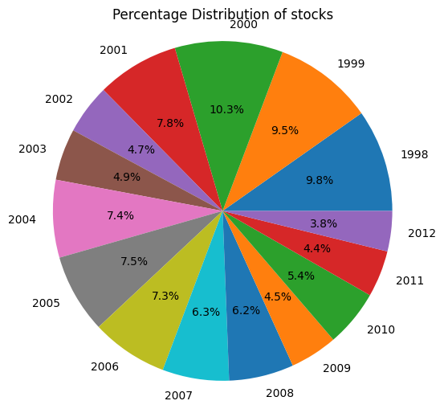

```python
yearly_production = df.groupby('year')['stocks'].sum()
plt.figure(figsize=(6, 6))
plt.pie(yearly_production, labels=yearly_production.index, autopct='%1.1f%%')
plt.title('Percentage Distribution of stocks')
plt.axis('equal')
plt.show()
```

#### 4. Plot and Understand the distribution of the variable "price per lb" using displot, and write your findings.

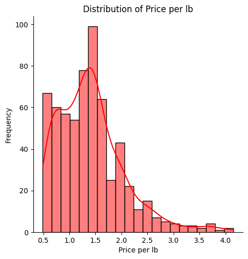

```python
sns.displot(df['priceperlb'], kde=True,color='red')
plt.title('Distribution of Price per lb')
plt.xlabel('Price per lb')
plt.ylabel('Frequency')
plt.show()
```

#### 5. Plot and understand the relationship between the variables 'numcol' and 'prodval' through scatterplot, and write your findings.

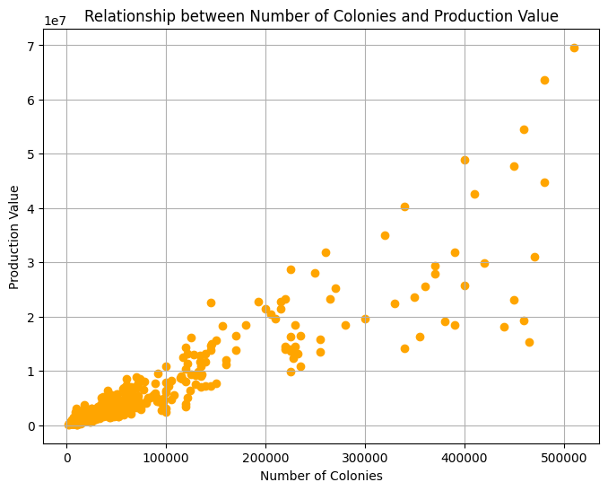

```python
plt.figure(figsize=(8, 6))
plt.scatter(df['numcol'], df['prodvalue'],color='orange')
plt.title('Relationship between Number of Colonies and Production Value')
plt.xlabel('Number of Colonies')
plt.ylabel('Production Value')
plt.grid(True)
plt.show()
```

- In the scatter plot we can find that there is a significantly linear relation between Number of Colonies and Production Values.
- Number of Colonies increases, then the Production Values also increases.

#### 6. Plot and understand the relationship between categorical variable 'year' and a numerical variable 'prodvalue' through boxplot, and write your findings.

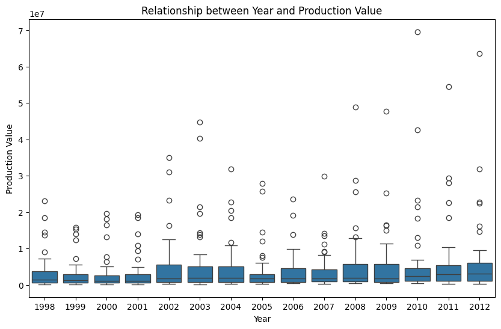

```python
plt.figure(figsize=(10, 6))
sns.boxplot(x='year', y='prodvalue', data=df)
plt.title('Relationship between Year and Production Value')
plt.xlabel('Year')
plt.ylabel('Production Value')
plt.show()
```

- The above box plot we can find that the highest no.of production were made in the years 2002,2008,2009 & 2012.
- Lowest production in the year 2000 and 2005.

#### 7. Visualize and understand the relationship between the multiple pairs of variables throughout different years using pairplot and add your inferences. (use columns 'numcol', 'yield percol', 'total prod', 'prodvalue','year')

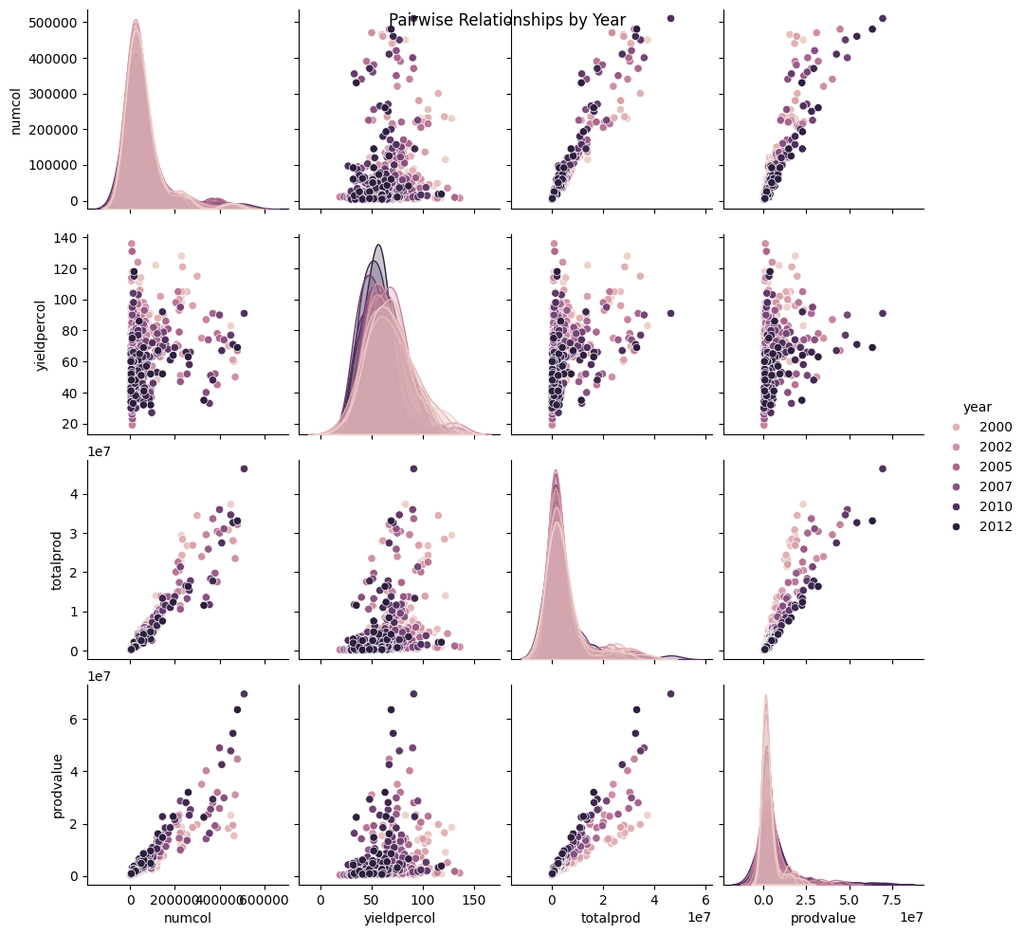

```python
df_filtered = df[['numcol', 'yieldpercol', 'totalprod', 'prodvalue', 'year']]
sns.pairplot(df_filtered, hue='year', diag_kind='kde')
plt.suptitle('Pairwise Relationships by Year')
plt.show()
```

#### 8. Display the correlation values using a plot and add your inferences. (use columns 'numcol', 'yield percol', 'total prod', 'stocks', 'price per lb', 'prodvalue')

```python
correlation_matrix = df[['numcol', 'yieldpercol', 'totalprod', 'stocks', 'priceperlb', 'prodvalue']].corr()
correlation_matrix
```

|  | numcol | yieldpercol | totalprod | stocks | priceperlb | prodvalue |
| --- | --- | --- | --- | --- | --- | --- |
| numcol | 1.000000 | 0.243515 | 0.953594 | 0.825929 | -0.232701 | 0.912796 |
| yieldpercol | 0.243515 | 1.000000 | 0.396252 | 0.367812 | -0.358646 | 0.278977 |
| totalprod | 0.953594 | 0.396252 | 1.000000 | 0.878830 | -0.264499 | 0.907236 |
| stocks | 0.825929 | 0.367812 | 0.878830 | 1.000000 | -0.305867 | 0.728560 |
| priceperlb | -0.232701 | -0.358646 | -0.264499 | -0.305867 | 1.000000 | -0.089567 |
| prodvalue | 0.912796 | 0.278977 | 0.907236 | 0.728560 | -0.089567 | 1.000000 |

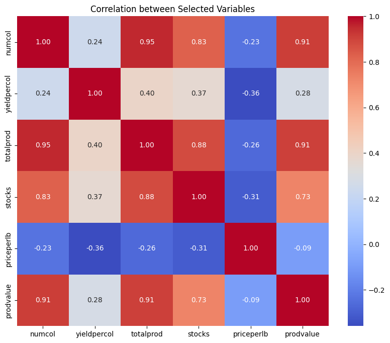

```python
plt.figure(figsize=(10, 8))
sns.heatmap(correlation_matrix, annot=True, cmap='coolwarm', fmt=".2f")
plt.title('Correlation between Selected Variables')
plt.show()
```

- **Numcol and totalprod**:
- There is a strong positive correlation (0.95), indicating that as the number of colonies increases, the total honey production also tends to increase significantly.
- **Numcol and prodvalue**:
- There is a strong positive correlation (0.91), indicating that as the number of colonies increases, the total production value (revenue) tends to increase significantly.
- **Totalprod and prodvalue**:
- There is a strong positive correlation (0.91), indicating a close relationship between the amount of honey produced and the resulting revenue generated. This suggests that higher production volumes tend to lead to higher overall revenue from honey sales.
- **Numcol and stocks**:
- There is a strong positive correlation (0.83), implying that as the number of colonies increases, the amount of honey in storage also tends to increase.
- **Numcol and yieldpercol**:
- There is a weak positive correlation (0.24), suggesting that as the number of colonies increases, the yield per colony tends to slightly increase as well.
- **Numcol and priceperlb**:
- There is a weak negative correlation (-0.23), suggesting that as the number of colonies increases, the price per pound of honey tends to slightly decrease.